# Part II - Ford GoBike System Data

## by Diane Uwiduhaye

## Investigation Overview

In this investigation I wanted to know how Gender, age,days of the week, type of the user affect the interest of people in bike riding in the San Francisco Bay Area.

## Dataset Overview

This data set includes information about individual rides made in a bike-sharing system covering the greater San Francisco Bay area. The dataset has a total of 183412 observations, and 15 variables.

I am going to present the key insights from the analysis I made on the dataset

## Distribution of duration in Seconds

It is observed that duration in seconds of bike riding is not easy to visualise as we can use the duration in minutes. After visualizing in minutes we could see that most of trips seem to be short trips which the duration for trips is around 10 minutes.

```
count    183412.000000
mean         12.101307
std          29.906496
min           1.016667
25%           5.416667
50%           8.566667
75%          13.266667
max        1424.066667
Name: duration_min, dtype: float64
```

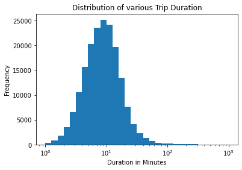

## Distribution bike users who used bike sharing for all trip

As per the next plot, the number of users who used bike sharing for all trip scheme are very few compared to those who didn't.

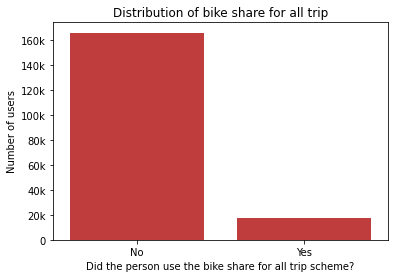

## Distribution of Bike User Type

In this project, we observed that most of users in the bike sharing scheme are those who have subscribed while a minimal number of users haven't.

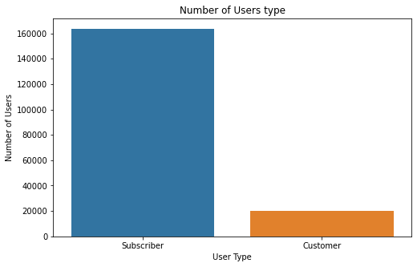

## Distribution of Gender among bike users

As observed in the next plot, most of the bike sharing users are male gender followed by Female gender type while a small group of users reported to have other gender types.

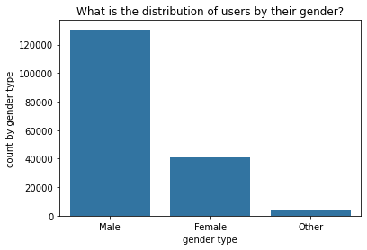

## Distribution by Age Category

The above donutchart shows that most of the bike sharing users' age falls in 30-59 age category followed by those who are less than 30 years while 60 years and above age category has the least number of users.

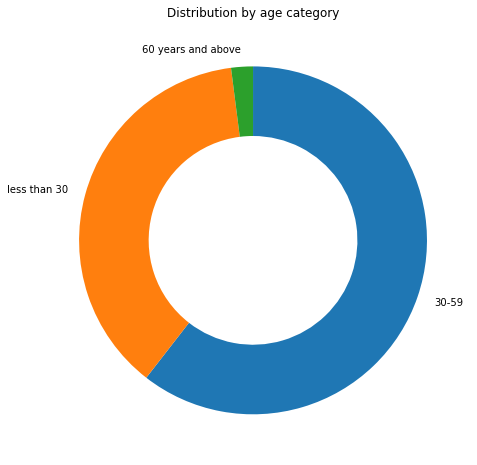

## Correlation between Age and bike users type

Most of bike sharing users fall under the ages between 19 and 62 years old. Users who have subscribed are the dominate the age range between 19 and 70 years olds. Among subscribers, the highest number of users were recorded among those with 31 years old. Among Customers (non-subscribers), the highest number of users was recorded amonth the users with 30 years old.

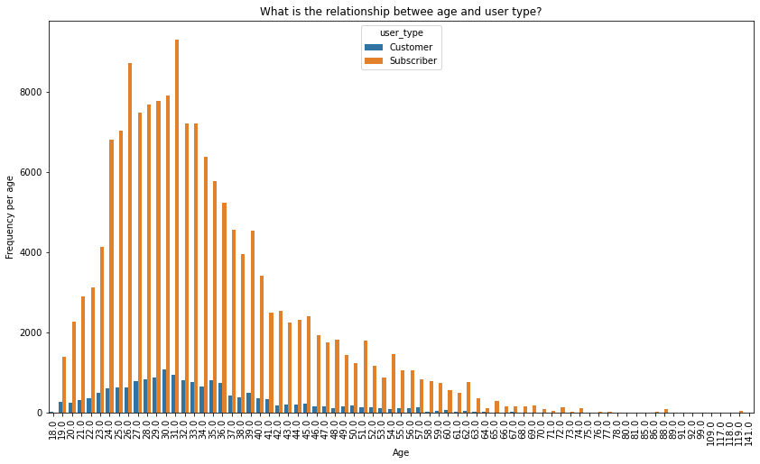

## Relationship between age category and gender of bike users

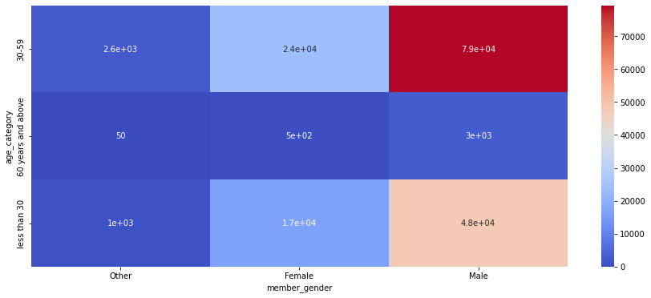